# Geography 176A

Lab 02: COVID-19 Pandemic

[Catherine Rauch](https://catherinerauch.github.io/geog176A.html)

##### *This report was current as of 9/05/2020*

## In this lab:

##### - manipulation and examination of New York Times COVID cases dataset

##### - creating visualizations and tables to report findings

##### - scaling by population and calculation of rolling averages

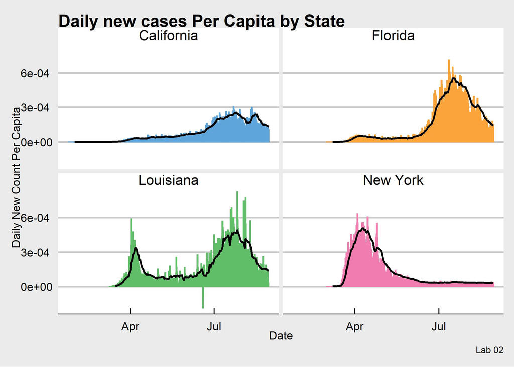

## Data:

##### - [dataset](https://raw.githubusercontent.com/nytimes/covid-19-data/master) with cumulative counts of coronavirus cases and deaths for each geography

##### - will use the historic (final counts at end of each day), county level data which is stored as an updating CSV

## Libraries

##### data wrangling tools

- library(tidyverse)

##### read files

- library(readxl)

##### rolling averages

- library(zoo)

##### plots and tables

- library(knitr)

#### The California Department of Public Health maintains a [current watch list](https://covid19.ca.gov/safer-economy/) of counties that are being monitored for worsening coronavirus trends. There are six criteria used to place counties on the watch list:

##### 1. Doing fewer than 150 tests per 100,000 residents daily (over a 7-day average)

##### 2. More than 100 new cases per 100,000 residents over the past 14 days…

##### 3. 25 new cases per 100,000 residents and an 8% test positivity rate

##### 4. 10% or greater increase in COVID-19 hospitalized patients over the past 3 days

##### 5. Fewer than 20% of ICU beds available

##### 6. Fewer than 25% ventilators available

#### Here, condition 2 will be examined with tables containing:

##### – total NEW cases in the 5 worst counties

##### – cumulative cases in the 5 worst counties

##### – number of unsafe counties

```r
addednewcases <- coviddata %>% # filter data by state of interest
  filter(state == stateofinterest) %>%
  group_by(county, date) %>%
  summarise(cases = sum(cases), fips) %>%
  mutate(newCases = cases - lag(cases)) %>% # creates new column with daily new cases
  ungroup()

mostnewcases <- addednewcases %>% # finds top 5 counties with most new cases per day
    filter(date == max(date)) %>%
    slice_max(newCases, n = 5) %>%
    select(county, newCases)

mostcumulativecases <- addednewcases %>% # finds top 5 counties with most cumulative cases
  filter(date == max(date)) %>%
  slice_max(cases, n = 5) %>%
  select(county, cases)
```

Most New Cases California Counties

| County | New Cases |
| --- | --- |
| Los Angeles | 809 |
| San Diego | 265 |
| Orange | 185 |
| Fresno | 159 |
| San Bernardino | 156 |

Most Cumulative Cases California Counties

| County | Total Cases |
| --- | --- |
| Los Angeles | 253,985 |
| Riverside | 55,073 |
| Orange | 52,121 |
| San Bernardino | 50,699 |
| San Diego | 42,742 |

### Per Capita Calculations

```r
PopulationEstimates <- read_excel("~/github/geog-176A-labs/data/PopulationEstimates.xls", skip = 2)
# dim(PopulationEstimates) # examine dimensions of excel file
# head(PopulationEstimates,5)

populationestimates <- PopulationEstimates %>% # select only necessary columns
  select(fips = "FIPStxt", state = "State", Area_Name, pop2019 = "POP_ESTIMATE_2019")


CovidandPopulation <- addednewcases %>%
  inner_join(populationestimates, by = "fips" ) # join to previous data


mostnewcasespc <- CovidandPopulation %>% # finds top 5 counties with daily new cases per capita
  filter(date == max(date)) %>%
  group_by(county) %>%
  mutate(casepercap = cases / pop2019) %>%
  ungroup() %>%
  slice_max(casepercap, n = 5) %>%
  select(county, casepercap)


mostcumulativecasespc <-CovidandPopulation %>% # finds top 5 counties with cumulative cases per capita
  filter(date == max(date)) %>%
  group_by(county) %>%
  mutate(newcasepercap = newCases / pop2019) %>%
  ungroup() %>%
  slice_max(newcasepercap, n = 5) %>%
  select(county, newcasepercap)
```

[output not shown]

[output not shown]

```r
numofdays <- 14

greaterthan100 <- CovidandPopulation %>%
  filter(date > (max(date) - numofdays)) %>%
  group_by(county, date) %>%
  summarise(ncases =  100000 * (sum(newCases) / pop2019)) %>%
  filter(ncases > 100)
```

##### 2 counties have more than 100 cases per 100,000 residents in the past 14 days, that leaves **55** counties deemed as safe.

California Counties with > 100 cases within 2 weeks

| County | Date | Cases Per 100,000 Residents |
| --- | --- | --- |
| Imperial | 2020-09-04 | 125.8174 |
| Kings | 2020-09-04 | 171.3090 |

### Examining impact of scale on COVID cases

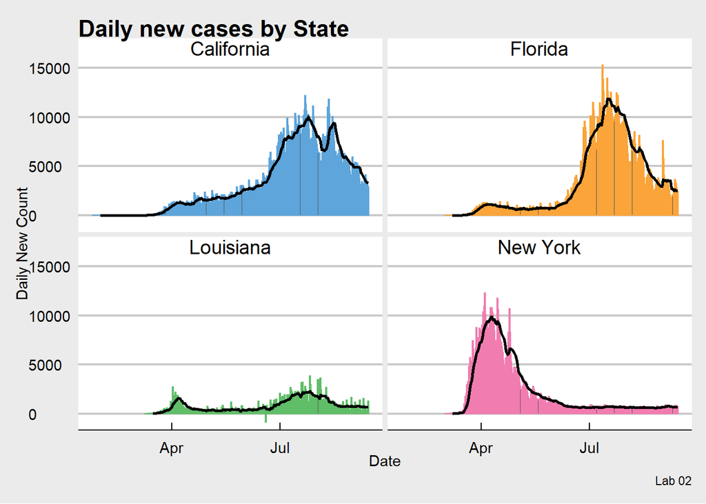

```r
statesofinterest <- c("New York", "California", "Louisiana","Florida")

coviddatastate <- coviddata %>%
  filter(state %in% statesofinterest) %>%
  group_by(state, date) %>%
  summarise(cases = sum(cases)) %>%
  # creates new column withe daily new cases
  mutate(newCases = cases - lag(cases),  roll7 = rollmean(newCases, 7, fill = NA, align="right")) %>%
  ungroup()

  coviddatastate %>%
  ggplot(aes(x = date, y = newCases)) +  geom_col(aes(y = newCases, col = state))+
  geom_line(aes(col = state)) + geom_line(aes(y = roll7), size = 1) +
  facet_wrap(~state, nrow = 2) + ggthemes::theme_economist_white()+ ggthemes::scale_color_few() +
  theme(legend.position = "bottom") +
  theme(legend.position = "NA") +
  labs(title = "Daily new cases by State", y = "Daily New Count", x = "Date",
       caption = "Lab 02")
```

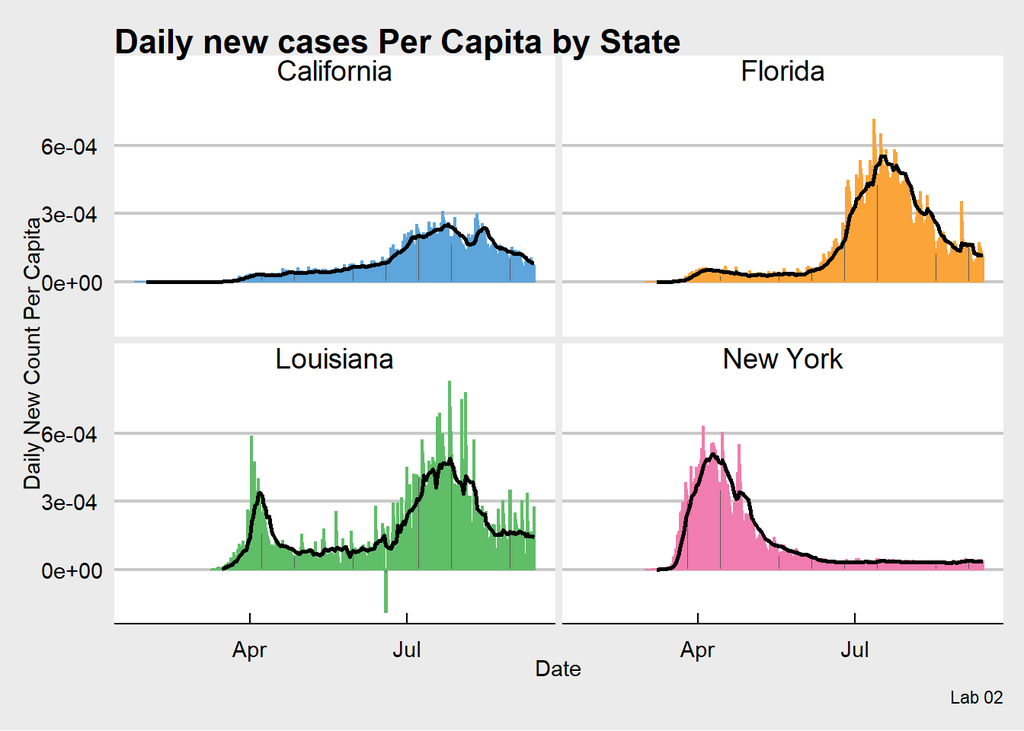

```r
coviddatastate %>%
  inner_join(populationestimates, by = c("state" = "Area_Name") ) %>%
  group_by(state, date) %>%
  summarise(newcases = sum(newCases), pop2019, .groups = "drop") %>%
  mutate(newcasepercap = (newcases / pop2019), roll7 = rollmean(newcasepercap, 7, fill = NA, align="right"))%>%
  ggplot(aes(x = date, y = newcasepercap)) +
  geom_col(aes(y = newcasepercap, col = state))+
  geom_line(aes(col = state)) + geom_line(aes(y = roll7), size = 1)+
  facet_wrap(~state, nrow = 2) + ggthemes::theme_economist_white() + ggthemes::scale_color_few() +
  theme(legend.position = "none") +
  labs(title = "Daily new cases Per Capita by State", y = "Daily New Count Per Capita", x = "Date",
       caption = "Lab 02")
```

This graph was scaled by population, and it can be seen that Louisiana’s situation is more dire while California’s appears better. California has the largest population among these states and after scaling, it can be seen that they have had the smallest reported spike in daily cases. New York and Florida are close together in population and appear to have a similar sized spike in daily cases. Whereas before the scaling it appeared Florida had the largest spike, and California and New York’s was similar. Although New York’s was in April while Florida’s happened in July. Louisiana has the smallest population by far with roughly 4.6 million (New York, California and Florida have a population greater than 19 million) but, after scaling, has the largest spike in daily new cases per capita.